# Why R

Peter von Rohr

3 Feb 2015

R has many advantages. There is a big and active community, there are a lot of packages available for a wide variety of statistical analyses, the two reasons why one should use R that I like most are

1. Fast Protoyping and
2. Good infrastructure for implementing literate programming approaches

## Fast Prototyping

Fast Prototyping` - stands for the fact that once you have an idea, it can be very quickly transformed into R-code. This is explained very nicely by Dirk Edelbuettel in a [Google Tech Talk](https://www.youtube.com/watch?v=UZkaZhsOfT4).

In short, imaging you have a dataset, like the one on eruption times and waiting times of the Old Faithful geyser in Yellowstone National Park, and you want to draw a histogram of the eruption times. In R this is just one statement.

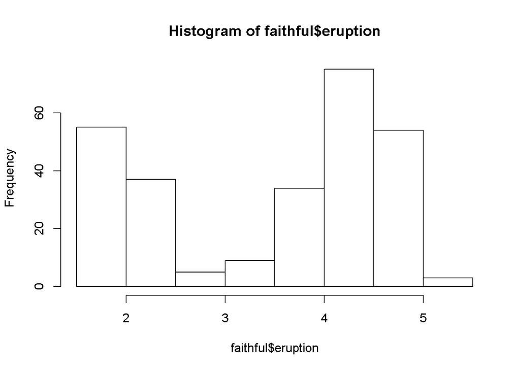

```r
hist(faithful$eruption)
```

Let us further assume that I want to draw markov chain samples from the empirical distribution and I want to show confidence levels of the drawn samples in a line-plot. And here it comes …

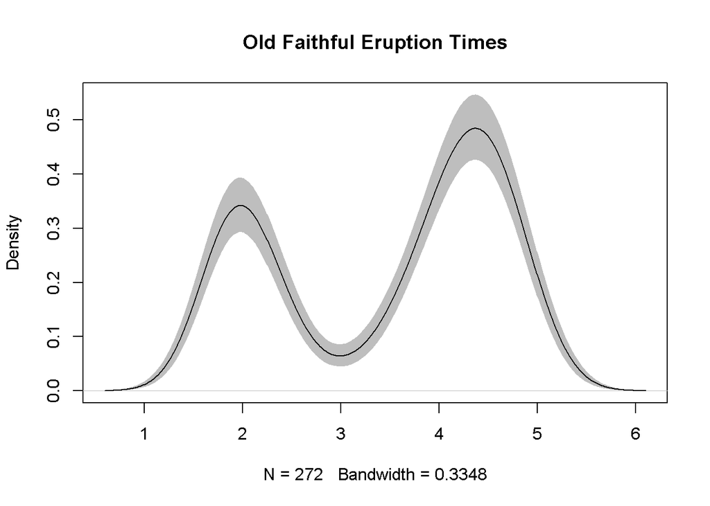

```r
vOfErTime <- faithful$eruptions
### # density fit
fitDensity <- density(vOfErTime)
### # markov chain samples
fitMC <- replicate(10000, {
  vSam <- sample(vOfErTime, replace = TRUE);
  vSamDens <- density(vSam, from = min(fitDensity$x),
                      to = max(fitDensity$x))$y
})
### # get quantiles based on samples
fitQuant <- apply(fitMC, 1,
                  quantile, c(0.025, 0.975))
plot(fitDensity, ylim = range(fitQuant), main = "Old Faithful Eruption Times")
polygon(c(fitDensity$x, rev(fitDensity$x)),
        c(fitQuant[1,], rev(fitQuant[2,])),
        col = 'grey', border = FALSE)
lines(fitDensity)
```

Let us have a moment here to appreciate what we just did. This is density fitting, drawing markov chain samples, computing quantiles of the samples and plotting everything in just seven statements. This example best shows what is really meant by `fast prototyping`.

The following list briefly explains what the seven statements are doing.

```
1. vOfErTime <- faithful$eruptions
```

just extracts the column with eruption times from the `faithful` dataframe into a vector called `vOfErTime`.

```
2. fitDensity <- density(vOfErTime)
```

fits a density to the vector of eruption times using R’s internal `density()` function. The help file `?density` gives the detail on how the fit is done. What is important to note here is that the function `density()` returns a list with components `x` and `y` which specify the fitted density.

```
3. fitMC <- replicate(10000, {
  vSam <- sample(vOfErTime, replace = TRUE);
  vSamDens <- density(vSam, from = min(fitDensity$x),
                      to = max(fitDensity$x))$y
})
```

The third statement samples markov chain (MC) replicates with replacements from the vector `vOfErTime`. The function `replicate()` is a wrapper to `sapply()` and all it does is replicating the expression given as the second argument as many times as specified by the first argument. In the above case the number of replications is 10000 and the expression to be replicated are two statements. First a sample with replacement is drawn from vector `vOfErTime` and second from this sample the density is computed and only the y-component of the density object is returned. The result of the whole statement is a matrix with 512 rows which corresponds to the length of y-component of the density object and with 10000 columns which is equal to the number of replicates.

```
4. fitQuant <- apply(fitMC, 1,
                  quantile, c(0.025, 0.975))
```

Quantiles are computed using the `apply()` function on the result matrix from the third statement. The first argument to `apply()` is the data object to operate on which in our case is `fitMC`. The second argument to `apply()` specifies the dimension index where 1 means rows and 2 stands for columns. The third argument to `apply()` is the function to be used on the data object. The remaining arguments are additional arugments to the function specified as the third argument to `apply()`.

```
5. plot(fitDensity, ylim = range(fitQuant), main = "Old Faithful Eruption Times")
```

opens a plotting device for the object `fitDensity` using the limit of the y-axis as specified by the range of the quantiles and the given main title of the plot.

```
6. polygon(c(fitDensity$x, rev(fitDensity$x)),
        c(fitQuant[1,], rev(fitQuant[2,])),
        col = 'grey', border = FALSE)
```

draws quantiles band around the density curve as a polygon. Because we have 512 points in both directions, the corners of the polygons are not really visible. The command `polygon()` accepts two vectors which define the vertices of the polygon to be drawn.

```
7. lines(fitDensity)
```

adds the density curve to the plot.

## Literate Programming

As already mentioned in a previous [post](http://charlotte-ngs.github.io/2015/01/09/BashScriptPOD) on how to use POD for documenting bash scripts, in literate programming, documents are written in natural language such as English intersperced with macros or snippets of code. Both description and the code is built from a single source and results of computations or graphics are shown directly after the code that generated those results.

Besides being very good programming practise to document the programming code, documents built using literate programming approaches offer a great level of reproducitility.

In R there are two different systems implementing a literate programming approach.

1. `Sweave` provides a flexible framework for mixing text and R code for automated document generation. A single source file contains both text and R code which are used to build a single output document. The output document contains the text together with the R code and the output of the code. Sweave has a modular design where different drivers are used for building different markup languages. In the default setting the text is written in LaTeX and the R-code is placed within the source document using the `noweb` syntax. For further documentation, I refer to the [Sweave user manual](https://stat.ethz.ch/R-manual/R-devel/library/utils/doc/Sweave.pdf) and to (Leisch 2002)
2. `knitr` is an alternative tool to Sweave. Documentation and demos are available on the [knitr website](http://yihui.name/knitr).

References

Leisch, Friedrich. 2002. “Sweave: Dynamic Generation of Statistical Reports Using Literate Data Analysis.” https://www.stat.uni-muenchen.de/~leisch/Sweave/Sweave-compstat2002.pdf.